# Homework 3

Author: Matthew J. Cossley

Last update: 11 March, 2022

## 0.

```r
# load the packages we will need
library(data.table)
library(ggplot2)

# clean session
rm(list=ls())

# basic id info
my_name <- "John Doe"
my_student_id <- "12345678"

# Please include the following line of code as well
set.seed(0)
```

## 1.

Consider an experiment in which two four-sided die are thrown.

**(a)** Create a `data.table` named `ans_1a` with two columns labelled `die1` and `die2` where these columns encode the **sample space** of this experiment. As a hint, the following shows the what the output of `ans_1a[1:8]` should produce for you. It’s up to you to determine how many observations in total `ans_1a` should have.

```
##    die1 die2
## 1:    1    1
## 2:    2    1
## 3:    3    1
## 4:    4    1
## 5:    1    2
## 6:    2    2
## 7:    3    2
## 8:    4    2
```

**(b)** Create a deep copy of `ans_1a` called `ans_1b` and then add a column to `ans_1b` called `X` and set it equal to the sum of the corresponding `die1` and `die2` values on a per row basis.

**(c)** Let $X$ be the random variable defined by the `X` column in `ans_1b`. What is $P(X<5)$? Store your result in a variable named `ans_1c`.

**(d)** Is the event defined as the set of all outcomes for which $X=2$ an elementary event? Store your answer (`"YES"` or `"NO"`) in a variable named `ans_1d`.

## 2.

For the following probability distribution:

| $x$ | 2 | 3 | 4 | 5 | 6 |
| --- | --- | --- | --- | --- | --- |
| $f(x)$ | .1 | .3 | .3 | .2 | .1 |

**(a)** Is $f(x)$ a valid probability distribution? Store your answer (`"YES"` or `"NO"`) in a variable named `ans_2a`.

**(b)** Calculate $E(X)$ store the result in a variable named `ans_2b`.

**(c)** Calculate $P(X \geq 4)$ store the result in a variable named `ans_2c`.

**(d)** Calculate $P(2 < X \leq 4)$ and store the result in a variable named `ans_2d`.

## 3.

Given the following probability distribution:

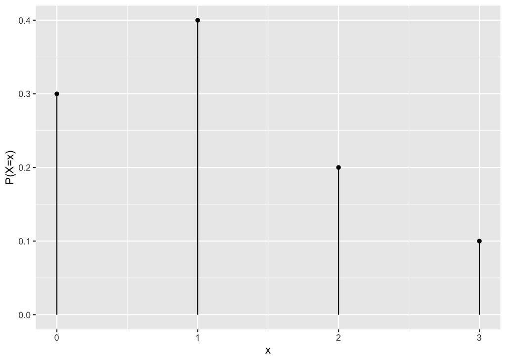

Find:

**(a)** Calculate $P(X \geq 2)$ and store your result in a variable named `ans_3a`.

**(b)** Calculate $P(0 < X \leq 2)$ and store your result in a variable named `ans_3b`.

**(c)** Calculate $E(X)$ and store your result in a variable named `ans_3c`.

**(d)** $Var(X)$ and store your result in a variable named `ans_3d`.

**(e)** $sd(X)$ and store your result in a variable named `ans_3e`.

## 4.

Consider the probability distributions for random vairbale $X$ and random variable $Y$ defined below.

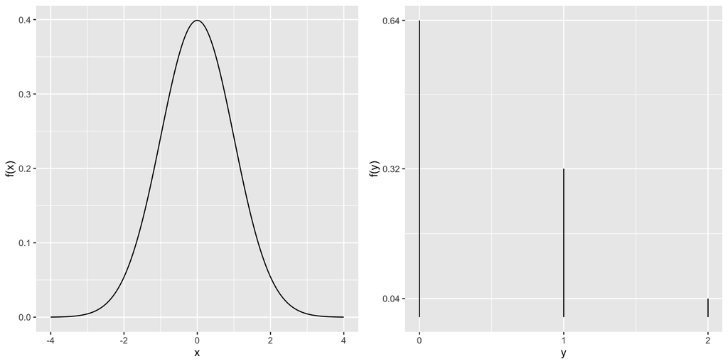

**a.** What is the population mean of $X$? Store your answer in a variable named `ans_4a`.

**b.** What is the population mean of $Y$? Sore your answer in a variable named `ans_4b`.

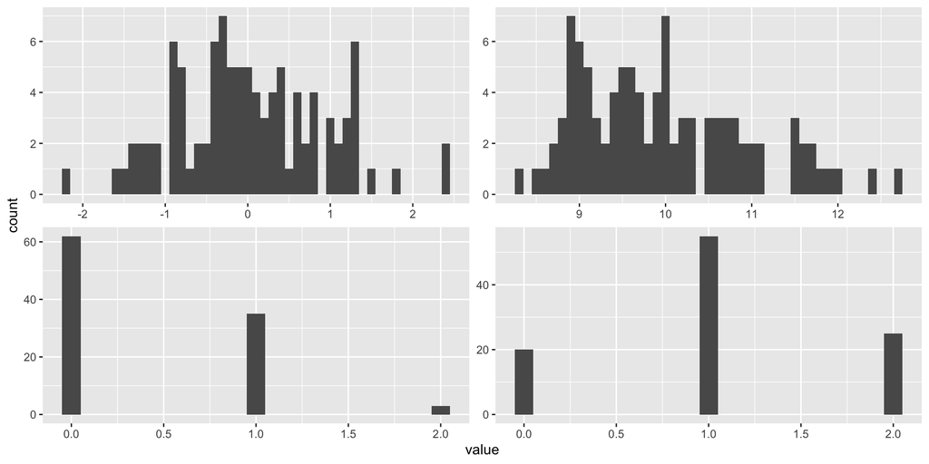

**c.** Which of the histograms above most likely corresponds to a sample from $X$? Please store your answer as one of the following:

- `ans_4c <- 'upper left'`
- `ans_4c <- 'lower left'`
- `ans_4c <- 'upper right'`
- `ans_4c <- 'lower right'`

**d.** Which of the histograms above most likely corresponds to a sample from $Y$? Please store your answer as one of the following:

- `ans_4d <- 'upper left'`
- `ans_4d <- 'lower left'`
- `ans_4d <- 'upper right'`
- `ans_4d <- 'lower right'`

## 5.

**a.** Use the `fread` function in the `data.table` library to read `https://crossley.github.io/cogs2020/data/criterion_learning/crit_learn.csv` into a `data.table` and store the result in a variable named `ans_5a`.

**b.** Create a new `data.table` that contains only rows of `ans_5a` for which `cnd` is `%in%` `c('Delay', 'Long ITI', 'Short ITI')`, and only the mean of the `t2c` column grouped by `sub` and `cnd`. Store your result in a variable named `ans_5b`.

**c.** Is `ans_5b` in wide or long format? Please use one of the following lines to store your result in a variable named `ans_4c`:

- `ans_5c <- 'wide'`
- `ans_5c <- 'long'`

**Note on 5d and 5e below:**

```r
# First, after using `fread` to read the cav file into a
# data.table (this step not shown here) you should end up
# with the variable `ans_5b` that looks like this:
ans_5b
##     sub       cnd  t2c_mean
##  1: 101     Delay  52.67191
##  2: 102     Delay 120.34433
##  3: 103     Delay 178.26180
##  4: 104     Delay 109.66122
##  5: 105     Delay  53.52605
##  6: 106     Delay 102.00000
##  7: 107     Delay  47.57143
##  8: 108     Delay  42.16742
##  9: 109     Delay 115.57906
## 10: 110     Delay 341.74123
## 11: 111     Delay 177.14844
## 12: 112     Delay  73.14226
## 13: 113     Delay 394.65690
## 14: 114     Delay  79.08571
## 15: 115     Delay  76.43311
## 16: 116     Delay 128.68033
## 17: 117     Delay 481.00000
## 18: 118     Delay  94.54545
## 19: 119     Delay 101.96957
## 20: 120     Delay  49.00000
## 21: 201  Long ITI  48.48847
## 22: 202  Long ITI 438.57422
## 23: 203  Long ITI  39.57702
## 24: 204  Long ITI  47.86475
## 25: 205  Long ITI  44.31224
## 26: 206  Long ITI  76.70186
## 27: 207  Long ITI  31.42588
## 28: 208  Long ITI  50.00656
## 29: 209  Long ITI  96.64344
## 30: 210  Long ITI  39.53786
## 31: 211  Long ITI  82.21684
## 32: 212  Long ITI 429.91016
## 33: 213  Long ITI  51.24000
## 34: 214  Long ITI  66.52688
## 35: 215  Long ITI 255.58797
## 36: 216  Long ITI  61.45333
## 37: 217  Long ITI  59.68831
## 38: 218  Long ITI  50.68396
## 39: 219  Long ITI  36.58774
## 40: 220  Long ITI  49.77652
## 41: 221  Long ITI 193.49778
## 42: 301 Short ITI  49.32506
## 43: 302 Short ITI 461.00000
## 44: 303 Short ITI  34.69036
## 45: 304 Short ITI  86.38281
## 46: 305 Short ITI  67.53906
## 47: 306 Short ITI  44.92668
## 48: 307 Short ITI  37.87552
## 49: 308 Short ITI  57.83984
## 50: 309 Short ITI  41.08889
## 51: 310 Short ITI 208.60938
## 52: 311 Short ITI  96.35156
## 53: 312 Short ITI  36.00000
## 54: 313 Short ITI 236.02734
## 55: 314 Short ITI  32.58503
## 56: 315 Short ITI 512.00000
## 57: 316 Short ITI 172.66016
## 58: 317 Short ITI 425.00000
##     sub       cnd  t2c_mean

# It is clear from this that `ans_5b` is in `long` format.
# This is because there is only one column that contains
# measurements of a dependent variable. In this case, that
# column is named `t2c_mean`.

# To convert this long format data.table into a wide format
# data.table, we use the `dcast` function:
d_wide <- dcast(ans_5b, sub ~ cnd, value.var='t2c_mean')

# The first argument we pass `dcast` is the data.table
# object that we want to convert from long to wide. The
# second argument that we pass is a `formula` that tells
# `dcast` what columns you want to keep as indicator columns
# (LHS side of the formula) and what columns you want to
# break out into multiple wide format columns (RHS of the
# formula).

# So, did it all work out okay?
d_wide
##     sub     Delay  Long ITI Short ITI
##  1: 101  52.67191        NA        NA
##  2: 102 120.34433        NA        NA
##  3: 103 178.26180        NA        NA
##  4: 104 109.66122        NA        NA
##  5: 105  53.52605        NA        NA
##  6: 106 102.00000        NA        NA
##  7: 107  47.57143        NA        NA
##  8: 108  42.16742        NA        NA
##  9: 109 115.57906        NA        NA
## 10: 110 341.74123        NA        NA
## 11: 111 177.14844        NA        NA
## 12: 112  73.14226        NA        NA
## 13: 113 394.65690        NA        NA
## 14: 114  79.08571        NA        NA
## 15: 115  76.43311        NA        NA
## 16: 116 128.68033        NA        NA
## 17: 117 481.00000        NA        NA
## 18: 118  94.54545        NA        NA
## 19: 119 101.96957        NA        NA
## 20: 120  49.00000        NA        NA
## 21: 201        NA  48.48847        NA
## 22: 202        NA 438.57422        NA
## 23: 203        NA  39.57702        NA
## 24: 204        NA  47.86475        NA
## 25: 205        NA  44.31224        NA
## 26: 206        NA  76.70186        NA
## 27: 207        NA  31.42588        NA
## 28: 208        NA  50.00656        NA
## 29: 209        NA  96.64344        NA
## 30: 210        NA  39.53786        NA
## 31: 211        NA  82.21684        NA
## 32: 212        NA 429.91016        NA
## 33: 213        NA  51.24000        NA
## 34: 214        NA  66.52688        NA
## 35: 215        NA 255.58797        NA
## 36: 216        NA  61.45333        NA
## 37: 217        NA  59.68831        NA
## 38: 218        NA  50.68396        NA
## 39: 219        NA  36.58774        NA
## 40: 220        NA  49.77652        NA
## 41: 221        NA 193.49778        NA
## 42: 301        NA        NA  49.32506
## 43: 302        NA        NA 461.00000
## 44: 303        NA        NA  34.69036
## 45: 304        NA        NA  86.38281
## 46: 305        NA        NA  67.53906
## 47: 306        NA        NA  44.92668
## 48: 307        NA        NA  37.87552
## 49: 308        NA        NA  57.83984
## 50: 309        NA        NA  41.08889
## 51: 310        NA        NA 208.60938
## 52: 311        NA        NA  96.35156
## 53: 312        NA        NA  36.00000
## 54: 313        NA        NA 236.02734
## 55: 314        NA        NA  32.58503
## 56: 315        NA        NA 512.00000
## 57: 316        NA        NA 172.66016
## 58: 317        NA        NA 425.00000
##     sub     Delay  Long ITI Short ITI

# Well, sorta... what's with all those NAs? It turns out
# that I should have been thinking more clearly when I wrote
# this question. In particular, since there are different
# number of subjects per condition, the resulting wide format
# columns won't have the same number of rows, and that leads
# awkwardness. The form of `d_wide` above is just about as good
# as we can do.

# Q: How will the question be marked?

# A: Everybody will get marks up pretty willy nilly on this
# problem up until the last bit where you need to make a
# plot. There, I will mark more normally.
```

**d.** If `ans_5b` is in long format, then convert it to wide format. If it is already wide format, then convert it to long format. Store your result in a variable named `ans_5d`. Please also be careful to not alter `ans_5b` in the process.

**e.** If `ans_5d` is in long format, then convert it to wide format. If it is already wide format, then convert it to long format. Store your result in a variable named `ans_5e`. Please also be careful to not alter `ans_5d` in the process.

**f.** Please recreate the following figure using `ans_5b` as the source of data being plotted. Store the result of your call to the `ggplot()` function in a variable named `ans_5f`.

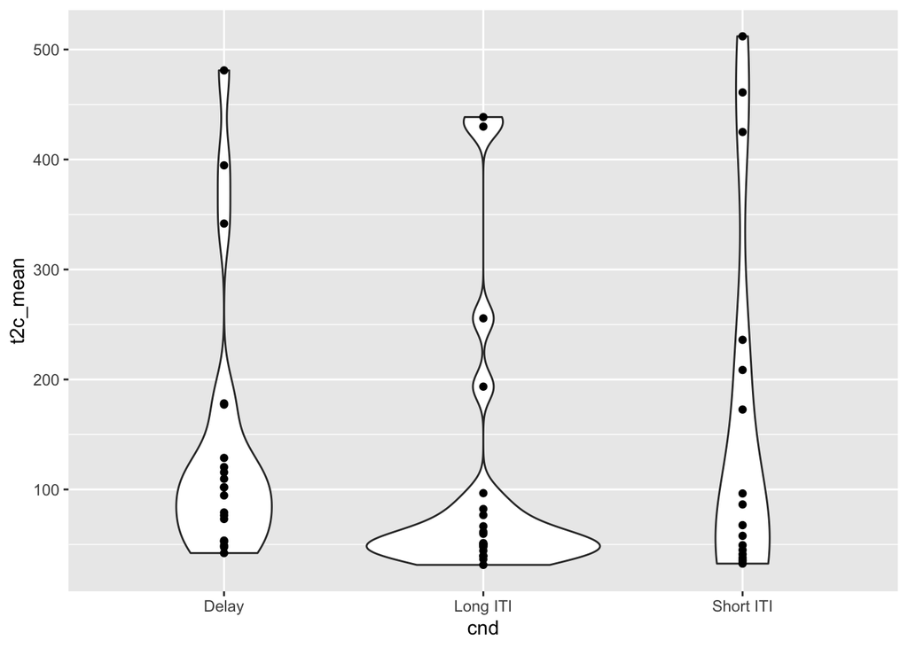

## 6. Final Check

A common error on these problem sets is to accidentally erase or overwrite variables from one question with those from another. Another common error is to name your variables slightly wrong (e.g., `Ans_1a` instead of `ans_1a`). Yet another common error is to include a line of code or two that generates an error, and sometimes this error is serious enough to prevent most or all of your script from running, in which case you will lose most or all of your marks for that assignment. All of these can be a very frustrating way to lose marks, but you will indeed lose marks if you make these mistakes, so you need to be very careful!

To ensure that this doesn’t happen to you, please run your entire `.R` script from start to finish. One way to do this is to use `Code > Run Region > Run All`, but of course there are shortcuts for everything so do as you wish. If there are any errors at all when you do this, it is essential that you address them.

After all of your code has executed from start to finish without and errors at all, then carefully inspect your workspace to ensure that the following variables are defined. A reasonable way to do this is to try to print each one of these variables to the console. If it is defined, then it will print without error.

```r
my_name
my_student_id
ans_1a
ans_1b
ans_1c
ans_1d
ans_2a
ans_2b
ans_2c
ans_2d
ans_3a
ans_3b
ans_3c
ans_3d
ans_3e
ans_4a
ans_4b
ans_4c
ans_4d
ans_5a
ans_5b
ans_5c
# ans_5d # my mistake here --- you don't need this.
# ans_5e # my mistake here --- you don't need this.
ans_5f
```

Finally, be sure that the file you submit to iLearn is a `.R` file and nothing else. Any other extension cannot be marked. This means do not submit `.Rmd`, `.RProj`, `.pdf`, `.html` or anything else. You must submit a `.R` file.